# Handling land crossings

Sangwon Hyun, Jacob Bien, and the Ocean Provinces working group

# Land crossings

Helper functions:

```r
all_points_between <- function(x0, x1, y0, y1, len = 10){
  all.x = seq(from = x0, to = x1, length=len)
  all.y = seq(from = y0, to = y1, length=len)
  return(cbind(x=all.x, y=all.y))
}


##' Checks if (x0, y0) and (x1, y1) crosses any land in \code{land_inds}.
##' @param x0 x0
##' @param y0 y0
##' @param x1 x1
##' @param y1 y1
##' @param land_inds A data frame whose names are x and y
##' @examples
##' \dontrun{
##' ## Simple test
##' start = data.frame(x=1,y=4)
##' end   = data.frame(x=4,y=1)
##' land_inds = expand.grid(1:(nn/2), 1:(nn/2)) %>% rename(x=Var1, y=Var2)
##' cross = check_cross_land(start$x, start$y, end$x, end$y, land_inds)
##' assertthat::assert_that(cross == TRUE)
##' }
check_cross_land <- function(x0, y0, x1, y1, land_inds, how_many_points_to_check = 30){

  ## Basic checks
  assertthat::assert_that(all(colnames(land_inds) == c("x", "y")))

  ## Identify all point centers
  all_pts = all_points_between(x0, x1, y0, y1, how_many_points_to_check)
  all_round_pts = all_pts %>% as_tibble %>% mutate(xround = round(x), yround=round(y)) %>% select(x=xround, y=yround) %>% unique()
  ## all_ceil_pts = all_pts %>% as_tibble %>% mutate(xceiling = ceiling(x), yceiling=ceiling(y), xfloor = floor(x), yfloor = floor(y)) %>% select(x=xceiling, y=yceiling)
  ## all_floor_pts = all_pts %>% as_tibble %>% mutate(xfloor = floor(x), yfloor=floor(y)) %>% select(x=xfloor, y=yfloor)
  ## all_round_pts = bind_rows(all_ceil_pts, all_floor_pts) %>% unique()

  ## return(any(pracma::distmat(all_pts, land_inds) <= 1))

  ## Check if they cross land
  m1 = land_inds
  m2 = all_round_pts
  intersection = intersect(m1, m2) ## inner_join(m1, m2)
  any_intersection = (nrow(intersection) != 0)
  return(any_intersection)
}
```

Example of how we’ll identify land crossings:

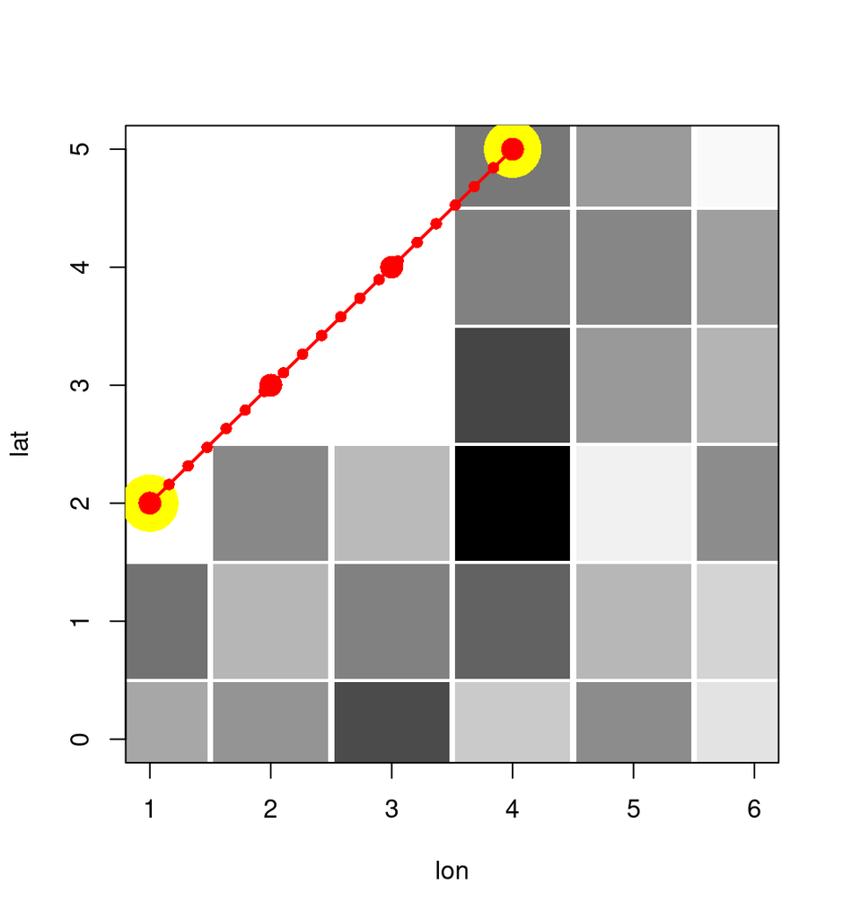

```r
nn = 6
mat0 = matrix(rnorm(nn^2), nrow = nn, ncol = nn)
rownames(mat0) = 1:nn
colnames(mat0) = 1:nn
mat = mat0
mat[1:(nn/2), 1:(nn/2)] = NA
matlong = mat %>% image_to_long_format() %>% as_tibble() %>% filter(!is.na(val))
base_r_plot(matlong[,"lon", drop=TRUE],
            matlong[,"lat", drop=TRUE],
            max(matlong[,"lat", drop=TRUE]),
            val = matlong[,"val", drop=TRUE] %>% range01(),
            colfun = function(cols){ cols %>% sapply(., function(col)rgb(0, 0, 0, col))},
            cex = 10)

start = c(x=1,y=4)
end   = c(x=4,y=1)

## Plot the points between |start| and |end|
points(x = start["x"], y = nn - start["y"], cex = 5, pch = 16,  col = 'yellow')
points(x = end["x"], y = nn - end["y"], cex = 5, pch = 16,  col = 'yellow')
segments(x0 = start["x"], y0 = nn-start["y"], x1 = end["x"], y1 = nn-end["y"],
         lwd = 2,  col='red')##x=start$x, y=start.$y)
all_pts = all_points_between(x0 = start["x"], y0 = nn-start["y"], x1 = end["x"],
                             y1 = nn-end["y"], 20)
all_round_pts = all_pts %>% as_tibble %>%
  mutate(xround = round(x), yround=round(y)) %>% select(x = xround, y = yround)
points(all_round_pts, col = 'red', pch = 16, cex = 2)
points(all_pts, col = 'red', pch = 16, cex = 1)
```

Form the cost matrix (27 x 27, since there are 27 out of 36 pixels that are non-NA) and calculate the OMD on a simulated example next. The first cost matrix shown is the one before preventing land-crossing; the next one is after.

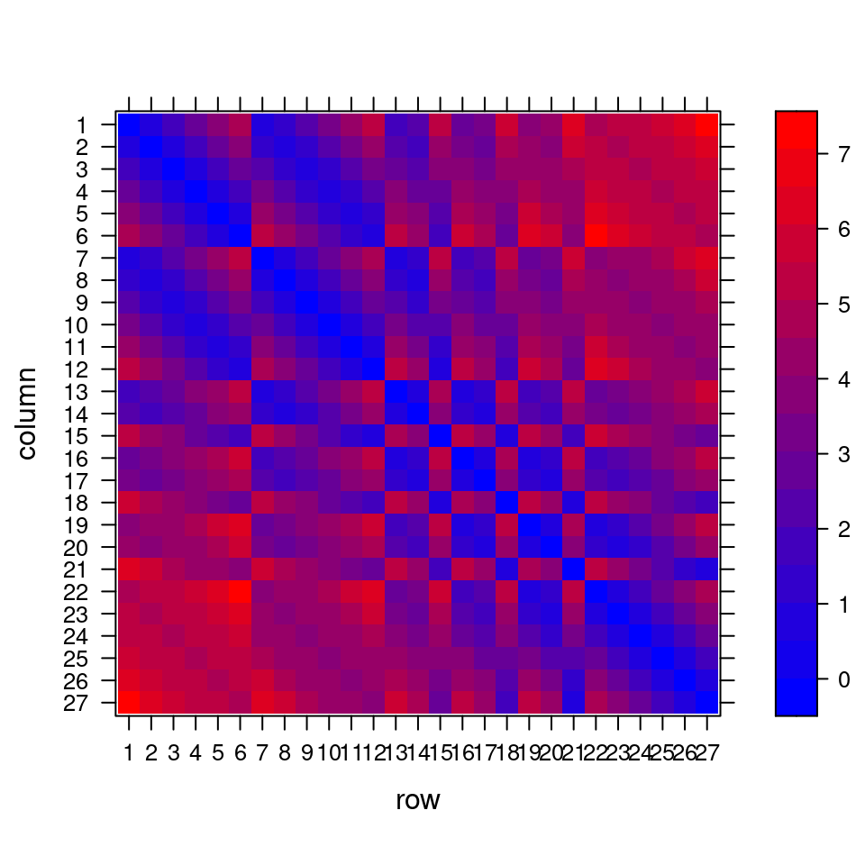

```r
## Form a 6 x 6 matrix with land on the second (topleft) quadrant.
nn = 6
mat0 = matrix(rnorm(nn^6, 10, 2) , nrow = nn, ncol = nn)
rownames(mat0) = 1:nn
colnames(mat0) = 1:nn
mat = mat0
mat[2+(1:(nn/2)), 2+(1:(nn/2))] = NA
land_inds = expand.grid(2+(1:(nn/2)), 2+(1:(nn/2))) %>% rename(x=Var1, y=Var2)
matlong = mat %>% image_to_long_format() %>% as_tibble() %>% filter(!is.na(val))
coords = matlong %>% select(lat, lon)

## Form the cost matrix
crossmat = matrix(NA, nrow = nrow(coords), ncol = nrow(coords))
for(istart in 1:nrow(coords)){
  for(iend in 1:nrow(coords)){
      start = coords[istart,] %>% rename(x=lon, y=lat)
      end = coords[iend,] %>% rename(x=lon, y=lat)
      cross = check_cross_land(start$x, start$y, end$x, end$y, land_inds)
      crossmat[istart, iend] = cross
  }
}

## Check that this is symmetric
costm_orig = costm = matlong %>% form_cost_matrix()
costm %>% drawmat_precise()
```

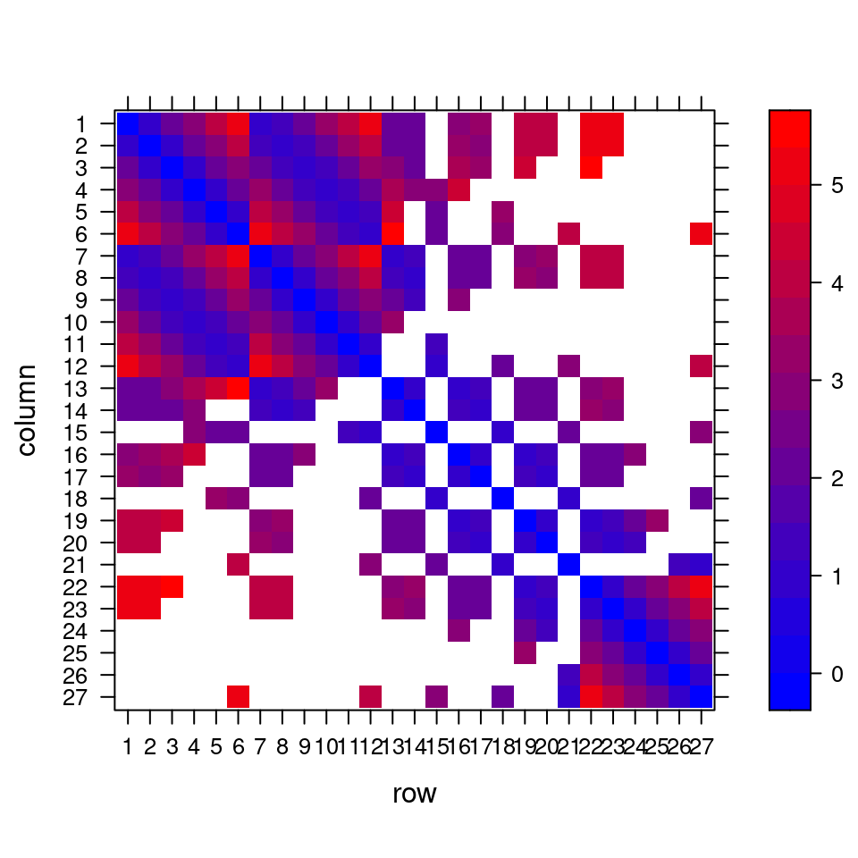

```r
costm[crossmat] = +Inf##1E10##Inf##1E10##Inf
costm %>% drawmat_precise()
```

```r
stopifnot(isSymmetric(costm))

## Normalize the other matrix
mat = mat/sum(mat, na.rm=TRUE)
othermat = (mat + 10* runif(length(mat)))
othermat = othermat/sum(othermat, na.rm=TRUE)
```

Now, we compute the optimal transport (with original and modified cost matrices `costm_orig` and `costm`) and plot it.

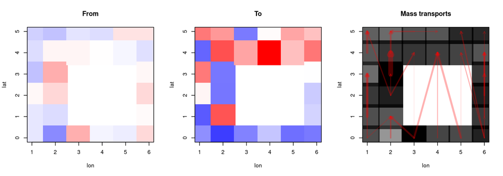

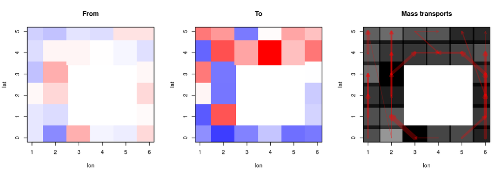

```r
## Estimate the OMD
M1_long = mat %>% image_to_long_format() %>% filter(!is.na(val))
M2_long = othermat %>% image_to_long_format() %>% filter(!is.na(val))
for(my_costm in list(costm_orig, costm)){
  res = omd(M1_long = M1_long,
            M2_long = M2_long,
            costm = my_costm,
            p = 1,
            type = "transport")
  inds = res$transport_object[,c("from", "to")]
  dists = sapply(1:nrow(inds), function(ii){ costm[inds[ii,1], inds[ii,2]]})
  plot_omd(res, cex=10)
}
```

# Darwin data

Now, let’s use real data. Here’s what Darwin climatology data looks like over time:

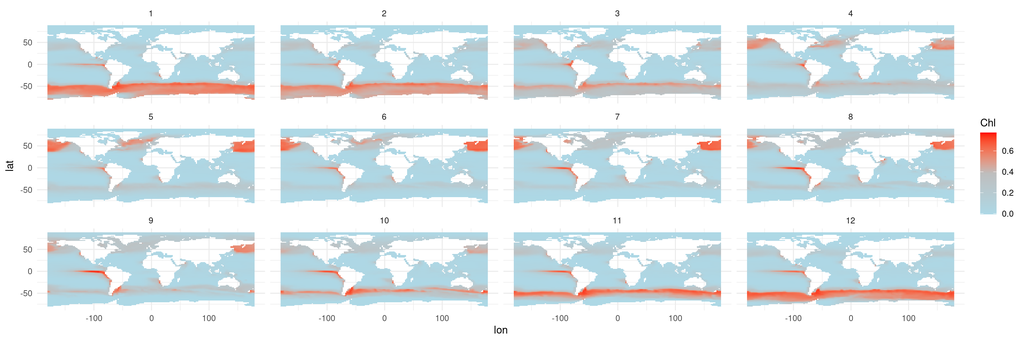

```r
darwin_dat %>%
  group_by(month) %>%
  ggplot() +
  facet_wrap(~ month, ncol = 4) +
  geom_raster(aes(y = lat, x = lon, fill = Chl)) +
  scale_fill_gradientn(colors = c("lightblue", "grey", "red"), guide="colorbar") +
  theme_minimal()
```

```r
  ## scale_fill_gradientn(colours = pal) +
  ## labs(title = 'Month: {frame_time}') ##, x = 'GDP per capita', y = 'life expectancy') -> p
```

We’ll compare Jan and Feb’s Darwin climatology data:

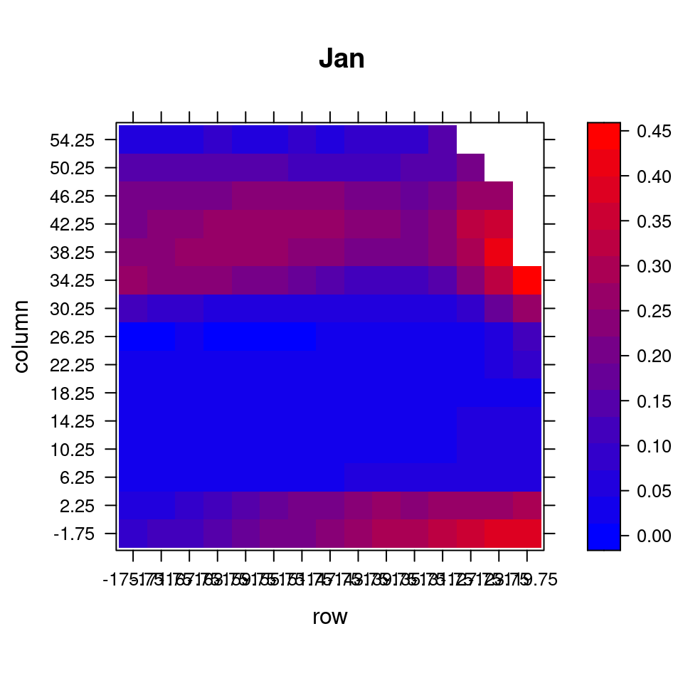

```r
## Helper function
get_mat <- function(df, latrange, lonrange){
  df %>% filter(lonrange[1] < lon,
                lon < lonrange[2],
                latrange[1] < lat,
                lat < latrange[2]) %>%
  make_mat()
}

mo = 1
lat = 19.8968 + 8
lon = -155.5828 + 8
boxsize = 30 ## 30
lonrange = lon + c(-1,1) * boxsize
latrange = lat + c(-1,1) * boxsize

darwin_dat = fread(file.path(datadir, filenames[1]), select=c("lat", "lon", "month", "Chl"))

mats = darwin_dat %>%
  group_by(month) %>%
  group_split() %>%
  lapply(., get_mat, latrange = latrange, lonrange = lonrange)
inds = mats %>% lapply(., function(mat) mat %>% is.na() %>% which(.==1, arr.ind = TRUE))
stopifnot(do.call(all.equal, inds))
land_ind = inds[[1]]

darwin_dat_box = darwin_dat %>%  group_by(month) %>%
  group_split() %>% lapply(., get_mat, latrange=latrange, lonrange=lonrange)

darwin_dat_box %>% .[[1]] %>% drawmat_precise(main = "Jan")
```

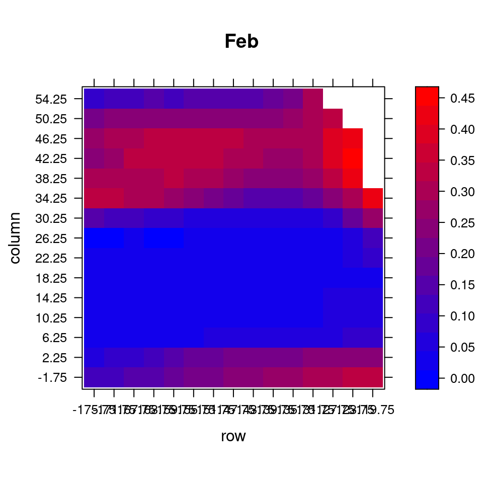

```r
darwin_dat_box %>% .[[2]] %>% drawmat_precise(main = "Feb")
```

Now, let’s (coarsen and) apply OMD.

```r
## M1_orig = M1 = darwin_dat_box %>% .[[1]]
## M1_na = which(is.na(M1), arr.ind=TRUE)
## ## M1 = M1 %>% smoothmat(10)
## M1[M1_na] = NA
## ## M1 %>% drawmat_precise()
## assertthat::assert_that(all(which(is.na(M1), arr.ind = TRUE) == M1_na))
## ## M2 = darwin_dat_box %>% .[[2]] %>% smoothmat(5)
M1 = darwin_dat %>% get_time_space_box(mo=1, latrange = latrange, lonrange = lonrange)
M2 = darwin_dat %>% get_time_space_box(mo=1, latrange = latrange, lonrange = lonrange)
M1_na = which(is.na(M1), arr.ind=TRUE)
costm = get_costm(M1, M1_na %>% as_tibble() %>% rename(x=row, y=col))
costm %>% drawmat_precise()
res = omd(M1_long, M2_long, costm = costm, p = 1)
plot_omd(res, cex=10)
```

[output not shown]

# Next up

- Make `get_costm()` faster.
- How to make it handle this gracefully and with minimal user input?
- Make smoothing handle NA values gracefully?
- `transport::transport()` is slow/impossible for large images (with more than 40,000 pixels, which is like a 200 x 200 image)